# Data study, how to increase succesful rates in future campaign

Almayra Edgina Rahma - 2802460930

2025-06-22

## Data preprocessing

### View data and check for missing and duplicated values

view columns of the data to get a general overview.

Preview

| X | age | job | marital | education | default | housing | loan | contact | month | day_of_week | duration | campaign | pdays | previous | poutcome | y |
| --- | --- | --- | --- | --- | --- | --- | --- | --- | --- | --- | --- | --- | --- | --- | --- | --- |
| 0 | 83 | retired | divorced | basic.4y | no | no | no | cellular | nov | tue | 242 | 1 | 3 | 3 | success | yes |
| 1 | 32 | services | married | high.school | no | no | no | telephone | may | tue | 190 | 3 | 999 | 0 | nonexistent | no |
| 2 | 31 | admin. | single | university.degree | no | yes | no | telephone | may | wed | 325 | 2 | 999 | 0 | nonexistent | no |
| 3 | 33 | admin. | single | university.degree | no | yes | no | telephone | aug | thu | 158 | 1 | 999 | 0 | nonexistent | no |
| 4 | 39 | services | married | high.school | no | yes | no | telephone | jul | mon | 158 | 1 | 999 | 0 | nonexistent | no |
| 5 | 57 | management | married | university.degree | no | no | no | cellular | jul | tue | 101 | 1 | 999 | 0 | nonexistent | no |

Job

| Var1 | Freq |
| --- | --- |
| admin. | 2033 |
| blue-collar | 1870 |
| entrepreneur | 294 |
| housemaid | 219 |
| management | 546 |
| retired | 366 |
| self-employed | 263 |
| services | 822 |
| student | 184 |
| technician | 1372 |
| unemployed | 196 |
| unknown | 65 |

marital

| Var1 | Freq |
| --- | --- |
| divorced | 892 |
| married | 4994 |
| single | 2338 |
| unknown | 14 |

education

| Var1 | Freq |
| --- | --- |
| basic.4y | 817 |
| basic.6y | 486 |
| basic.9y | 1243 |
| high.school | 1915 |
| illiterate | 6 |
| professional.course | 1043 |
| university.degree | 2379 |
| unknown | 349 |

default

| Var1 | Freq |
| --- | --- |
| no | 6491 |
| unknown | 1747 |

house loan

| Var1 | Freq |
| --- | --- |
| no | 3749 |
| unknown | 205 |
| yes | 4284 |

loan

| Var1 | Freq |
| --- | --- |
| no | 6741 |
| unknown | 205 |
| yes | 1292 |

contact

| Var1 | Freq |
| --- | --- |
| cellular | 5232 |
| telephone | 3006 |

month

| Var1 | Freq |
| --- | --- |
| apr | 529 |
| aug | 1189 |
| dec | 38 |
| jul | 1481 |
| jun | 1074 |
| mar | 105 |
| may | 2729 |
| nov | 827 |
| oct | 149 |
| sep | 117 |

day

| Var1 | Freq |
| --- | --- |
| fri | 1524 |
| mon | 1676 |
| thu | 1769 |
| tue | 1599 |
| wed | 1670 |

previous outcome

| Var1 | Freq |
| --- | --- |
| failure | 836 |
| nonexistent | 7136 |
| success | 266 |

outcome (y axis)

| Var1 | Freq |
| --- | --- |
| no | 7329 |
| yes | 909 |

In general, the categorical variables doesn’t have inconsistent categories, although a few can be renamed to be clearer and more accurate like category names in ‘month’ and ‘day_of_the_week’ column. Missing values in job category can be mutated to be in ‘unknown’ category

check the datas histogram to get a clear distribution of the numerical variables

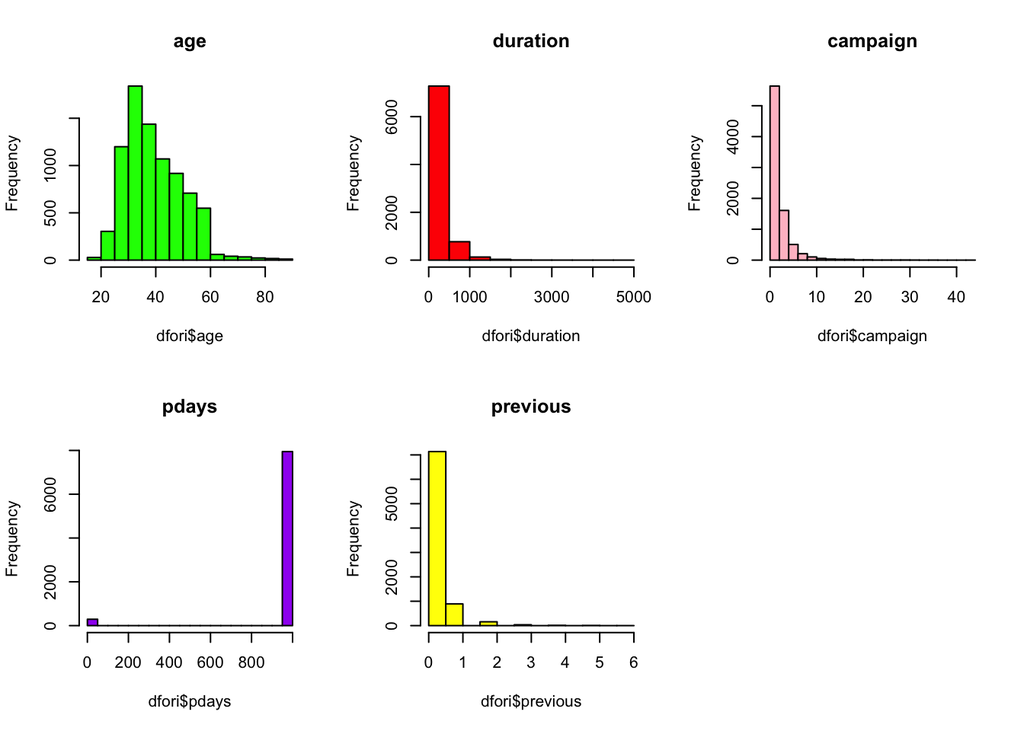

Age

```
##    Min. 1st Qu.  Median    Mean 3rd Qu.    Max.
##   17.00   32.00   38.00   39.93   47.00   89.00
```

Duration

```
##    Min. 1st Qu.  Median    Mean 3rd Qu.    Max.    NA's
##     4.0   102.0   180.0   258.2   319.8  4918.0      12
```

Duration variable has a few missing value that needs to be removed

number of contact during campaign

```
##    Min. 1st Qu.  Median    Mean 3rd Qu.    Max.
##   1.000   1.000   2.000   2.565   3.000  43.000
```

days since last contact

```
##    Min. 1st Qu.  Median    Mean 3rd Qu.    Max.
##     0.0   999.0   999.0   963.9   999.0   999.0
```

pdays variable is heavily dominated by naisy data ‘999’ which supposed to indicate ‘never been contacted’, this data should not be treated as outlier but instead be mutated into categorical data

previous number of contact

```
##    Min. 1st Qu.  Median    Mean 3rd Qu.    Max.
##  0.0000  0.0000  0.0000  0.1697  0.0000  6.0000
```

The previous variable is heavily dominated by zeros until the 3rd quartile. however the maximum value is 6. it will be too risky if outliers in this variable are to be removed. If the outliers in this variable are removed, then all values in this variable will all be zero

check for duplicated data

```
## [1] 0
```

since there are no duplicated data, there is no need to remove them

remove missing values

```
## [1] 0
```

missing values are removed

### Handle Outliers

Using boxplot to check for outliers, then use winsorization method to turn outliers into the maximum IQR value. Not every variable would need outlier removal. ‘pdays’, ‘duration’, and ‘previous’ variable have important values that might risk changing the data if outliers are to be removed. therefore, these variables would be mutated into categorical variables. On the other hand, ‘age’ and ‘campaign’ variable are cleaned.

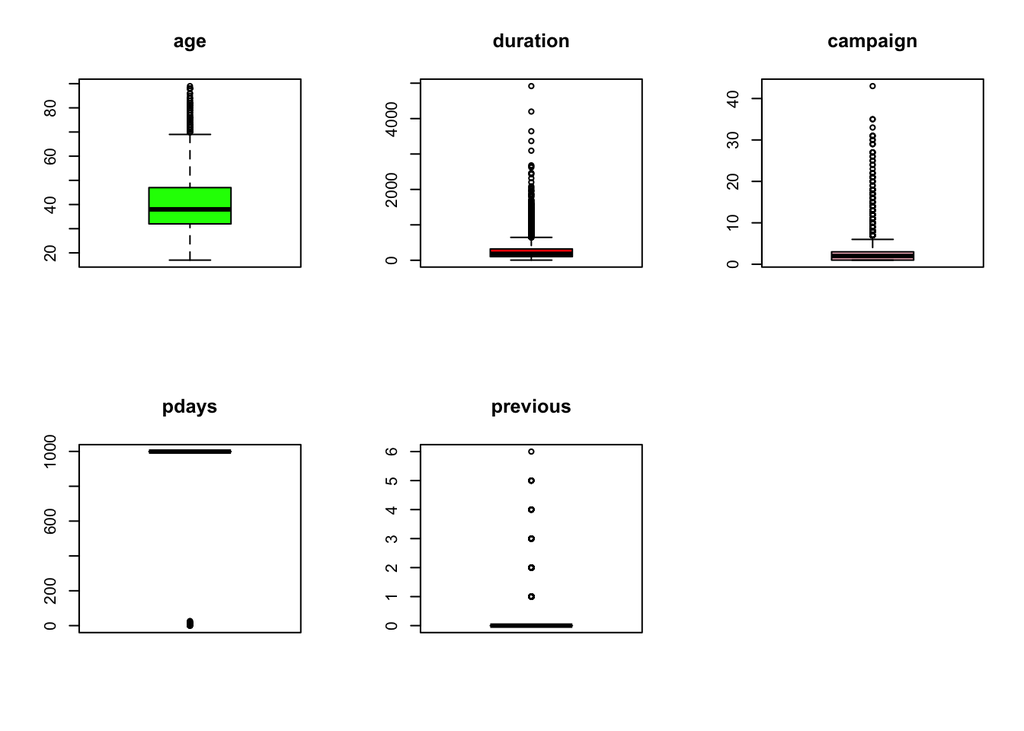

after removal of outlers

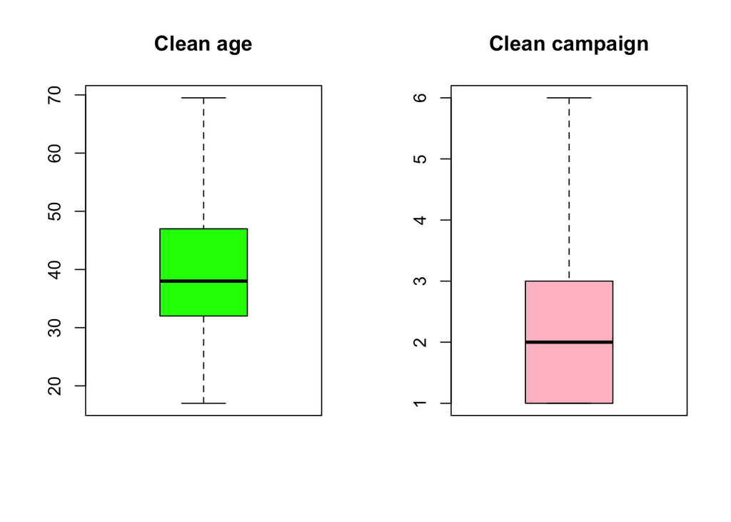

### Cleaned data

The values in job, education, moth, day_of_the_week variable are renamed, and all categorical variables are turned into factor data types. New variables made from categorizing numerical data: age and pdays. and a new variable made from calculating the sum of two variable (campaign and previous) is used to create a total contact variable

Cleaned data preview

| X | age | job | marital | education | default | housing | loan | contact | month | day_of_week | duration | campaign | pdays | previous | poutcome | y | age_group | recency_level | total_count_score | duration_cat | total_countCat |
| --- | --- | --- | --- | --- | --- | --- | --- | --- | --- | --- | --- | --- | --- | --- | --- | --- | --- | --- | --- | --- | --- |
| 0 | 69 | retired | divorced | 4 years | no | no | no | cellular | November | tuesday | 242 | 1 | 3 | 3 | success | yes | above 50 | Recent | 4 | short | multiple times |
| 1 | 32 | services | married | high school | no | no | no | telephone | May | tuesday | 190 | 3 | 999 | 0 | nonexistent | no | between 30 to 50 | Never | 3 | short | few times |
| 2 | 31 | admin | single | university degree | no | yes | no | telephone | May | wednesday | 325 | 2 | 999 | 0 | nonexistent | no | between 30 to 50 | Never | 2 | short | few times |
| 3 | 33 | admin | single | university degree | no | yes | no | telephone | August | thursday | 158 | 1 | 999 | 0 | nonexistent | no | between 30 to 50 | Never | 1 | short | once |
| 4 | 39 | services | married | high school | no | yes | no | telephone | July | monday | 158 | 1 | 999 | 0 | nonexistent | no | between 30 to 50 | Never | 1 | short | once |
| 5 | 57 | management | married | university degree | no | no | no | cellular | July | tuesday | 101 | 1 | 999 | 0 | nonexistent | no | above 50 | Never | 1 | short | once |

### Summary statistics and initial exploration

Central tendency and variance

summary of numerical variables

| variable | mean | median | standard_deviation | variance | IQR | minimum | maximum |
| --- | --- | --- | --- | --- | --- | --- | --- |
| age | 39.84 | 38 | 10.20 | 104.06 | 15 | 17 | 69 |
| campaign | 2.27 | 2 | 1.56 | 2.42 | 2 | 1 | 6 |
| duration | 258.23 | 180 | 266.85 | 71208.04 | 218 | 4 | 4918 |
| pdays | 963.82 | 999 | 183.63 | 33719.44 | 0 | 0 | 999 |
| previous | 0.17 | 0 | 0.49 | 0.24 | 0 | 0 | 6 |
| total_count_score | 2.44 | 2 | 1.59 | 2.53 | 2 | 1 | 9 |

the output shows that duration and pdays variable has the highest standard deviation value, meaning the values in the data are very spread out. Datas with these issue are better segmented into categories since the widly spread out numbers can lead to valuable information. On the other side, the variable ‘campaign’, ‘previous’, and ‘total_count_score’ has the lowest sd value meaning that the values are generally more close to each other and less spread out.

summary table - comparing age with multiple categorical variable (job, education, marital)

Job - age

| job | count | mean | median | standard_deviation | variance | minimum | maximum |
| --- | --- | --- | --- | --- | --- | --- | --- |
| admin | 2028 | 38.25 | 36 | 9.04 | 81.71 | 21 | 69 |
| blue-collar | 1868 | 39.31 | 38 | 9.03 | 81.49 | 20 | 69 |
| entrepreneur | 293 | 40.70 | 39 | 8.98 | 80.71 | 20 | 60 |
| housemaid | 219 | 45.62 | 45 | 10.07 | 101.41 | 23 | 69 |
| management | 545 | 42.35 | 41 | 9.23 | 85.27 | 23 | 69 |
| retired | 366 | 59.88 | 59 | 7.38 | 54.45 | 26 | 69 |
| self-employed | 263 | 39.86 | 39 | 9.40 | 88.33 | 23 | 60 |
| services | 821 | 37.61 | 36 | 9.25 | 85.49 | 20 | 60 |
| student | 184 | 26.03 | 26 | 4.85 | 23.54 | 17 | 44 |
| technician | 1370 | 38.43 | 36 | 8.52 | 72.54 | 22 | 69 |
| unemployed | 196 | 39.77 | 39 | 8.92 | 79.51 | 23 | 66 |
| unknown | 65 | 44.14 | 45 | 9.92 | 98.37 | 24 | 61 |

marital - age

| marital | count | mean | median | standard_deviation | variance | minimum | maximum |
| --- | --- | --- | --- | --- | --- | --- | --- |
| divorced | 891 | 44.61 | 44 | 9.86 | 97.31 | 25 | 69 |
| married | 4983 | 42.13 | 41 | 9.81 | 96.16 | 22 | 69 |
| single | 2330 | 33.09 | 32 | 7.60 | 57.70 | 17 | 69 |
| unknown | 14 | 42.29 | 36 | 12.89 | 166.22 | 27 | 66 |

The marital category shows that majority of the population is married with a spread out range of age from 22-69. And a small percentage of the population are divorced with individuals as young as 25

education - age

| education | count | mean | median | standard_deviation | variance | minimum | maximum |
| --- | --- | --- | --- | --- | --- | --- | --- |
| illiterate | 6 | 48.33 | 49.5 | 9.69 | 93.87 | 34 | 60 |
| 4 years | 815 | 46.89 | 47.0 | 11.27 | 127.12 | 18 | 69 |
| 6 years | 486 | 39.98 | 39.0 | 8.97 | 80.52 | 18 | 69 |
| 9 years | 1240 | 38.84 | 38.0 | 9.43 | 88.89 | 17 | 69 |
| high school | 1910 | 37.80 | 36.0 | 9.71 | 94.21 | 19 | 69 |
| professional course | 1041 | 39.70 | 38.0 | 9.46 | 89.40 | 22 | 69 |
| university degree | 2372 | 39.13 | 36.0 | 9.86 | 97.14 | 21 | 69 |
| unknown | 348 | 42.90 | 42.0 | 11.28 | 127.17 | 19 | 69 |

The table shows that people with lower levels of education (illiterate - 4 years) tend to be older than the higher level education categories

## Relationship analysis

### Variable relationships

correlation chart of age, duration, and total contacts compared to outcome. from the correlation chart it is visible that duration has the highest correlation with outcome. With a positive value of 0.39, this indicates that higher the duration value equals to higher chances of success in the outcome

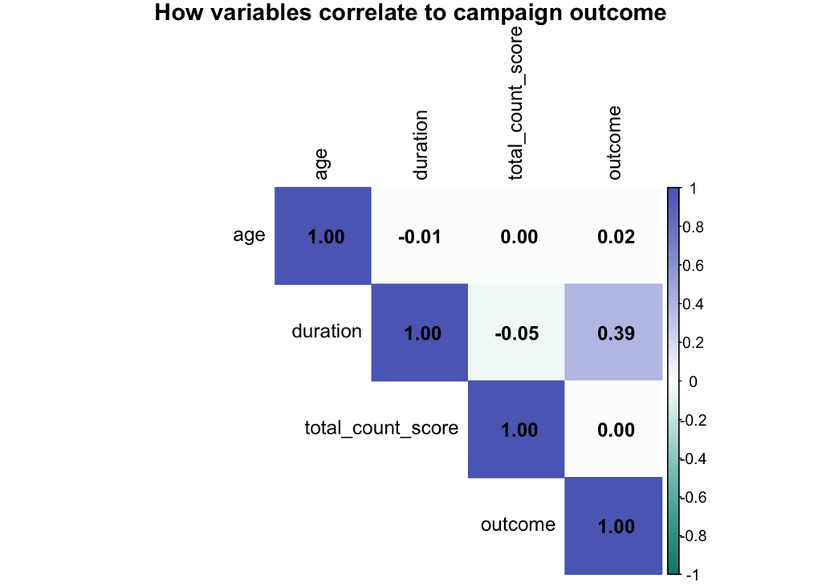

contact - outcome

|  | no | yes |
| --- | --- | --- |
| cellular | 4466 | 757 |
| telephone | 2843 | 152 |

people are more likely to subscribe when contacted by cellular rather when contacted by telephone

previous outcome - outcome

|  | no | yes |
| --- | --- | --- |
| failure | 727 | 108 |
| nonexistent | 6484 | 633 |
| success | 98 | 168 |

The table shows that people who previously subscribed are more likely to subscribe rather than those who previously did not. And people who have been previously contacted, no matter the outcome, have higher chances of subscribing rather than those who are newly contacted

month of campaign - outcome

|  | no | yes |
| --- | --- | --- |
| March | 51 | 54 |
| April | 435 | 94 |
| May | 2555 | 169 |
| June | 951 | 116 |
| July | 1350 | 129 |
| August | 1057 | 130 |
| September | 69 | 48 |
| October | 81 | 68 |
| November | 738 | 85 |
| December | 22 | 16 |

### Feature Engineering

New variables are made to further ease and enhance analysis

new variables

| age_group | recency_level | total_count_score |
| --- | --- | --- |
| above 50 | Recent | 4 |
| between 30 to 50 | Never | 3 |
| between 30 to 50 | Never | 2 |
| between 30 to 50 | Never | 1 |
| between 30 to 50 | Never | 1 |
| above 50 | Never | 1 |

age group variable is made by categorizing age into 3 different groups (<30, 30-50, >50). Recency level is made by converting pdays numbers into categories (999 = never, >10 = old, <10=recent). total_count_score variable is made by calculating the sum of previous and campaign to get the number of the total times a person is contacted

### Interactive visualization of relationships

Comparing 2 categorical variables

[interactive chart not shown]

The chart comparing housing status with loan status shows that people with personal loans are more likely to also have housing loans. And from both bars it is shown that people in general are more likely to have loans

Comparing 1 numeric and one categorical data

[interactive chart not shown]

this histogram shows that people from the younger generation tend to be single whereas the older generation have higher counts of being married or divorced

Multi dimentional chart

[interactive chart not shown]

this bar chart shows that individuals who subsribes to a deposit across occupation status either don’t have any loans or only have housing loans. It is highly unlikely for individuals who have both personal loans and housing loans subscribe to a deposit

## Story telling and recommendations

### Data storytelling

[interactive chart not shown]

this bar chart shows that individuals who were previously subscribed are more likely to subscribe again with majority of 63% from all previous subsribers who subscribed again.

[interactive chart not shown]

From the bar chart above, it is presented that individuals with university level education have the highest percentage of subscribing again.

[interactive chart not shown]

This bar chart shows that individuals who are occupied as manager have the highest percentages of subscribing again

[interactive chart not shown]

Based on the bar chart, it is shown that the higher the contact duration, then the higher the cances of successful outcome

[interactive chart not shown]

The histogram shows a clear shift of dominance when duration is higher than 400 seconds. Contacts with duration higher than 400 seconds have dominantly more successful outcome

[interactive chart not shown]

This heatmap shows that individuals with personal loans and housing loans have a very short contact duration

[interactive chart not shown]

This heatmap shows that individuals who previously have never been contacted have shorter contact duration

### Business Recommendation

1. Look for customers who are university graduates or those who work in management. These individuals are the most likely to continue subscribing for the current and future deposits.
2. Avoid contacting customers with personal loans, they tend to have very short contact duration wich leads to smaller chance of subscription. Also keep track of previously contacted individuals since new customers have shorter contact duration, although avoid calling a customer too many times during a campaign since more frequently contacted customer leads to shorter contact duration

## Video link

### YouTube link

https://youtu.be/yQ55uoyE_m4

### Gdrive link

https://drive.google.com/file/d/1tnTQktrWp5ywHvpUe2redx_RJ7wyMrVQ/view?usp=sharing